# HW5

**Note:** Before submitting your document, re-run all your R code chunks by clicking the down-arrow next to “Run” in the document’s menu bar and selecting “**Restart R and Run All Chunks**”. Then click “Preview” and go through each answer to make sure the R code and any associated output is provided.

Necessary libraries

An experiment was run to examine the combined effects of Exercise regimes on weight loss in dogs. They hypothesized that this may depend on diet, so used a factorial experimental design. The experiment used four commercial dog foods (Food_A - Food_D) and three exercise regimes (WALK: daily walking, LOW: 30 min run 2x/week, HIGH: 30 min run 6 days per week). They recruited 96 dogs from a nearby vet clinic and assigned each to one of the 4 food brands and one of the 3 exercise regimes. Weights were collected at the beginning of the experiment and after 3 months. Responses were recorded as % change in weight after 3 months for each dog.

Here are the data:

```
'data.frame':   96 obs. of  4 variables:
 $ Dog           : int  1 2 3 4 5 6 7 8 9 10 ...
 $ Food          : chr  "Food_C" "Food_A" "Food_B" "Food_A" ...
 $ Exercise      : chr  "WALK" "LOW" "LOW" "HIGH" ...
 $ percent_change: num  -3.9 -3.5 -22.2 -27.4 -0.7 -2.7 -11.6 -4.7 -7.4 9.5 ...
```

### 0.0.1 1.1

**Create the Design table for this experiment. Use `Exercise` as the focal treatment. Explain your choices for EU and Replicate.**

| Structure | Variable | Type | #levels | Replicate | EU |
| --- | --- | --- | --- | --- | --- |
| Focal Trt | Exercise | Cat | 3 | Food | Dog |
| Moderator Trt | Food | Cat | 4 | None | Dog |
| Combo Trt | Excercise:Food | Cat | 12 | None | Dog |
| Design | Dog | Cat | 96 |  |  |
| Response | % Change in Weight | Num | 96 |  |  |

> The EU is certainly `Dog`, since that is the only part of the experiment that receives a single level of treatment. Food receives multiple levels, and exercise is the treatment.

### 0.0.2 1.2

**Does the data.frame need to be updated to match the design table? If so, make necessary changes:**

### 0.0.3 1.3

**Make a plot of the data, separating by focal and moderator variables as done in lab.**

**1) Does it look like the different exercise regimes affected weight loss differently?** Is this a question about main, specific, or interaction effects?

**2) Does the differences among exercise regimes seem to change between the foods?** Is this a question about main, specific, or interaction effects?

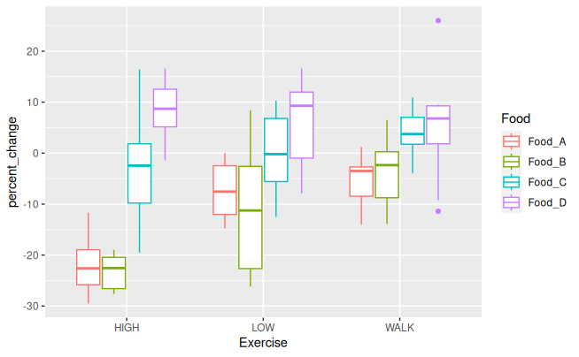

> 1. It does. If it did not, we would expect the box plots to look more alike each other, but there are definitely differences between the three regimes. This is a question about the interaction effects, since we are comparing the response variables of two treatments to see if there is a difference.
> 2. Yes they do. While some foods have very different results across different regimes, others have much less obvious differences, like Food_D which looks similar across the board. This is a question about interactions, comparing the combination of exercise and food across different treatment levels, as opposed to specifically percent change in a single Exercise:Food.

### 0.0.4 1.4

Write a linear model to estimate **specific effects** of exercise at each level of food.

### 0.0.5 1.5

**Compare the 3 exercise regimes for each type of food. Use `contrasts()` to make a table of `trt.vs.ctrl` comparisons for each type of food, using `WALK` as the control regime. Produce confidence intervals such that the chance that ANY of the confidence intervals do not include the true value is less than 5%.**

**Can you conclude that there are different effects of any of these 3 exercise regimes on weight gain using any of the 4 foods? Use** $\alpha = 0.05$**.**

```
NOTE: A nesting structure was detected in the fitted model:
    Exercise %in% Food
```

```
Food = Food_A:
 contrast    estimate   SE df lower.CL upper.CL t.ratio p.value
 HIGH - WALK  -16.337 4.05 84    -28.6    -4.04  -4.033  0.0002
 LOW - WALK    -1.913 4.05 84    -14.2    10.39  -0.472  0.8384

Food = Food_B:
 contrast    estimate   SE df lower.CL upper.CL t.ratio p.value
 HIGH - WALK  -19.550 4.05 84    -31.8    -7.25  -4.826  <.0001
 LOW - WALK    -7.362 4.05 84    -19.7     4.94  -1.817  0.1331

Food = Food_C:
 contrast    estimate   SE df lower.CL upper.CL t.ratio p.value
 HIGH - WALK   -7.463 4.05 84    -19.8     4.84  -1.842  0.1266
 LOW - WALK    -4.138 4.05 84    -16.4     8.16  -1.021  0.4941

Food = Food_D:
 contrast    estimate   SE df lower.CL upper.CL t.ratio p.value
 HIGH - WALK    3.200 4.05 84     -9.1    15.50   0.790  0.6424
 LOW - WALK     0.713 4.05 84    -11.6    13.01   0.176  0.9688

Confidence level used: 0.99375
Conf-level adjustment: dunnettx method for 2 estimates
P value adjustment: dunnettx method for 2 tests
```

> Yes! We can conclude that there are differences for HIGH exercise for at least two foods, Food_A and Food_B.

### 0.0.6 1.6

**Answer the similar question using an ANOVA. Can you conclude that there are different effects among any of these 3 exercise regimes on weight gain using any of the 4 foods? Use** $\alpha = 0.05$**. What is the difference between this question and the one in 1.5?**

```
Analysis of Variance Table

Response: percent_change
              Df Sum Sq Mean Sq F value    Pr(>F)
Food           3 6289.9 2096.62 31.9373 7.128e-14 ***
Food:Exercise  8 3105.1  388.13  5.9123 5.361e-06 ***
Residuals     84 5514.4   65.65
---
Signif. codes:  0 ‘***’ 0.001 ‘**’ 0.01 ‘*’ 0.05 ‘.’ 0.1 ‘ ’ 1
```

> Yes, we can! With `a = 0.05`, we can see that `Food:Exercise` has a p-value below it, so we know that the exercise regimes differ for at least one food type. This question doesn’t indicate which of the regimes may be different, just that one is (so it doesn’t test each specific effect).

### 0.0.7 1.7

**Did effects of changing to either HIGH or LOW exercise change among diets?**

**Calculate interaction effects for the HIGH-WALK and LOW-WALK contrasts across foods. Use `pairwise` contrasts for each contrast class among foods, and adjust your confidence intervals for the number of contrast classes.** **Use** $\alpha = 0.05$.

**Use the CLD function to group the contrasts for each food into groups that cannot be distinguished. Again, adjust the confidence level fo the number of contrast classes.**

Write a complete statement describing a significant interaction contrast that you observe.

```
Exercise_effect = HIGH - WALK:
 Food_effect_on_Exercise_effects_pairwise estimate   SE df lower.CL upper.CL t.ratio p.value
 Food_A - Food_B                              3.21 5.73 84    -15.5   21.947   0.561  0.9434
 Food_A - Food_C                             -8.88 5.73 84    -27.6    9.860  -1.549  0.4132
 Food_A - Food_D                            -19.54 5.73 84    -38.3   -0.803  -3.410  0.0054
 Food_B - Food_C                            -12.09 5.73 84    -30.8    6.647  -2.110  0.1584
 Food_B - Food_D                            -22.75 5.73 84    -41.5   -4.015  -3.971  0.0009
 Food_C - Food_D                            -10.66 5.73 84    -29.4    8.072  -1.861  0.2527

Exercise_effect = LOW - WALK:
 Food_effect_on_Exercise_effects_pairwise estimate   SE df lower.CL upper.CL t.ratio p.value
 Food_A - Food_B                              5.45 5.73 84    -13.3   24.185   0.951  0.7772
 Food_A - Food_C                              2.23 5.73 84    -16.5   20.960   0.388  0.9800
 Food_A - Food_D                             -2.62 5.73 84    -21.4   16.110  -0.458  0.9678
 Food_B - Food_C                             -3.23 5.73 84    -22.0   15.510  -0.563  0.9427
 Food_B - Food_D                             -8.07 5.73 84    -26.8   10.660  -1.409  0.4971
 Food_C - Food_D                             -4.85 5.73 84    -23.6   13.885  -0.847  0.8320

Confidence level used: 0.991666666666667
Conf-level adjustment: tukey method for comparing a family of 4 estimates
P value adjustment: tukey method for comparing a family of 4 estimates
Exercise_effect = HIGH - WALK:
 Food_effect_on_Exercise_effects_pairwise estimate   SE df t.ratio p.value .group
 Food_B - Food_D                            -22.75 5.73 84  -3.971  0.0009  a
 Food_A - Food_D                            -19.54 5.73 84  -3.410  0.0054  a
 Food_B - Food_C                            -12.09 5.73 84  -2.110  0.1584   b
 Food_C - Food_D                            -10.66 5.73 84  -1.861  0.2527   b
 Food_A - Food_C                             -8.88 5.73 84  -1.549  0.4132   b
 Food_A - Food_B                              3.21 5.73 84   0.561  0.9434    c

Exercise_effect = LOW - WALK:
 Food_effect_on_Exercise_effects_pairwise estimate   SE df t.ratio p.value .group
 Food_B - Food_D                             -8.07 5.73 84  -1.409  0.4971  a
 Food_C - Food_D                             -4.85 5.73 84  -0.847  0.8320  ab
 Food_B - Food_C                             -3.23 5.73 84  -0.563  0.9427   b
 Food_A - Food_D                             -2.62 5.73 84  -0.458  0.9678   b
 Food_A - Food_C                              2.23 5.73 84   0.388  0.9800    c
 Food_A - Food_B                              5.45 5.73 84   0.951  0.7772    c

P value adjustment: tukey method for comparing a family of 4 estimates
P value adjustment: tukey method for comparing a family of 6 estimates
significance level used: alpha = 0.991666666666667
NOTE: If two or more means share the same grouping symbol,
      then we cannot show them to be different.
      But we also did not show them to be the same.
```

> Of all the contrasts, only two have p values that are below our chosen alpha, and they are both in the HIGH-WALK contrast and are when switching from Food A or B to D. We are unable to establish any difference between the effect of A to D or B to D, however the two are different from all other estimates in HIGH-WALK.

### 0.0.8 1.8

**Repeat the last question using ANOVA. Compare the minimum p-value for the pairwise interaction contrasts and the p-value from the ANOVA.**

```
Analysis of Variance Table

Response: percent_change
              Df Sum Sq Mean Sq F value    Pr(>F)
Exercise       2 1684.5  842.27 12.8301 1.373e-05 ***
Food           3 6289.9 2096.62 31.9373 7.128e-14 ***
Exercise:Food  6 1420.5  236.75  3.6064  0.003132 **
Residuals     84 5514.4   65.65
---
Signif. codes:  0 ‘***’ 0.001 ‘**’ 0.01 ‘*’ 0.05 ‘.’ 0.1 ‘ ’ 1
```

> The p-value from the anova analysis most closely matches the average of the two p values for A to D and B to D for HIGH-WALK. They’re similar, relatively, and the p-value for the anova splits the difference between the two.